# Lecture 7: Applications II - Operations with multiple datasets

This class will be entirely self-directed

- Learn basic commands for importing/exporting datasets
- Practice this module's concepts in a quiz
- More info will be posted on Canvas at the start of class

## I. Import Libraries

```python
# the "numPy" library is used for mathematical operations
# the "matplotlib" library is for generating graphs
# the "pandas" library is for manipualting datasets

import numpy as np
import matplotlib.pyplot as plt
import pandas as pd
```

## II. Importing / Exporting Datasets

There are many formats to store data out there.

- So far we've only imported ".csv" files
- Also common: Excel (".xlsx") and Stata (".dta")
- Pandas can handle all these formats! Full list:

https://pandas.pydata.org/docs/reference/io.html#

Read/write from CSV

```python
# Import a CSV file (READ)
carfeatures = pd.read_csv("data/features.csv")

# Save the dataset to another csv file (WRITE)
carfeatures.to_csv("data/features_stored.csv")
```

Read/write from Stata (".dta")

```python
# Read a Stata file
carfeatures = pd.read_stata("data/features.dta")

# Write a stata file
carfeatures.to_stata("data/features_stored.dta")
```

Read/write from Excel (".xlsx")

```python
#  Read
carfeatures = pd.read_excel("data/features.xlsx")

# Write
carfeatures.to_excel("data/features_stored.xlsx")

# Note: If the information is contained in a specifc sheet of the excel file
# carfeatures = pd.read_excel("data/features.csv",sheet_name = "Sheet1")
```

## III. Quiz Structure

The day of the quiz I will ...

- Provide different datasets with yearly data
- Give more specific instructions.
- Below, you will see that type of questions that will be asked.
- The idea is for you to apply known concepts to new data
- You have 50 minutes to complete the assignment

Questions

(exact wording may change in quiz, but exercise will be very similar)

(a) Create two normal random variables ...

- Call them "vec_x" and "vec_z"
- To generate each variable, use loc = 2, scale = 5, size = 1000
- Plot a histogram of each variable
  - Label the axes and title
  - Each graph should have a different title

To get full points, plot the histograms on a grid (See Lecture 6)

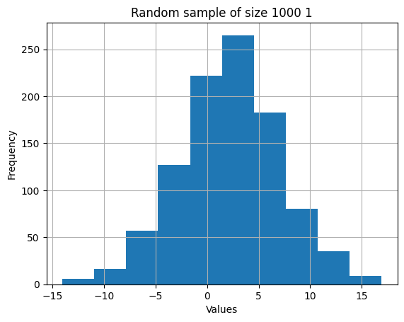

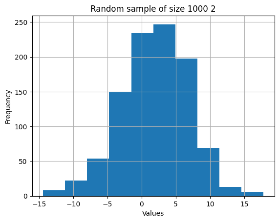

```python
vec_x = np.random.normal(loc=2, scale=5, size=1000)
vec_z = np.random.normal(loc=2, scale=5, size=1000)
ax = plt.axes()

plt.hist(x=vec_x)
plt.xlabel("Values")
plt.ylabel("Frequency")
plt.title("Random sample of size 1000 1")
ax.grid()
plt.show()

ax = plt.axes()
plt.hist(x=vec_z)
plt.xlabel("Values")
plt.ylabel("Frequency")
plt.title("Random sample of size 1000 2")
ax.grid()
plt.show()
```

(b) Create a new variable "vec_y" by the formula

$ y = x^2 + 2x + 5$

- Use element-by-element vector multiplicaiton (no loops)
- Produce a scatter plot of "vec_y" against "vec_x"
- Label the axes and the title
- Change the color to "red", "green" or "purple" (you choose)

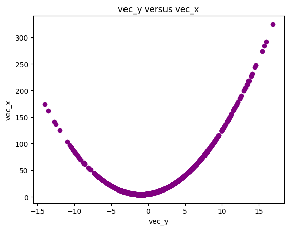

```python
vec_y=vec_x**2+2*vec_x+5
plt.scatter(vec_x,vec_y, color = "purple")
plt.xlabel("vec_y")
plt.ylabel("vec_x")
plt.title("vec_y versus vec_x")
```

(c) Creates two lists with ...

- The names of the datasets
- The years of the datasets (type manually based on the dataset names)

```python
datanames = ["one.csv","two.csv","three.csv"]
datayears = [2004,2010,2020]
```

(d) Create a loop that ...

- Goes over the list of years
- If the year $\ge$ 2010, print the message

$\qquad$ "This dataset contains information on or after 2010.

- If the year $<$ 2010, print the message

$\qquad$ "This dataset contains information before 2010"

```python
for i in datayears:
    if >= 2010:
        print("This dataset contains information on or after 2010")
    else:
        print("This dataset contains information before 2010")
```

(e) Create a for loop that ...

- Reads multiple ".csv" files and
- Converts them to ".xlsx" files
- Note: Make sure to know how to read/write in subfolders

Hint: Create a new list with the ".xslx" names and use a for loop with numbering

```python
list_csv = ['data/features.csv', 'data/features_stored.csv']
list_excel = []
index=1
for csv in list_csv:
    read_csv_file = pd.read_csv(csv)
    read_csv_file.to_excel('data/file' + str(index) + '.xlsx')
    excel_file = pd.read_excel('data/file' + str(index) + '.xlsx')
    list_excel.append(excel_file)
    index = index + 1
```

(f) Create a loop that ...

- Reads multiple ".csv" files
- Creates a numeric vector by
  - Adding/Subtracting/Mutiplying/Diving two or more variables
- Plots a histogram of the transformed variable
  - Numbers the figures
  - Labels the axes
  - Labels the title

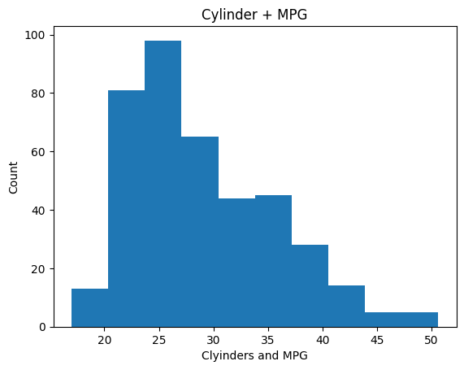

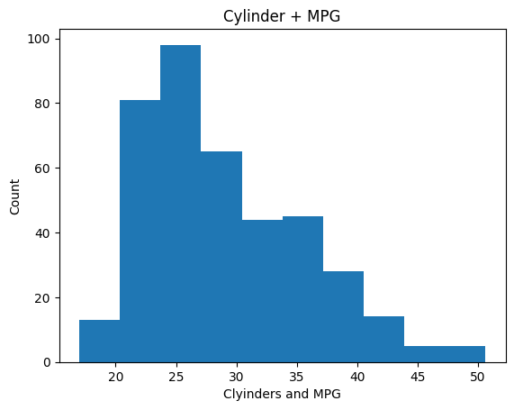

```python
for csv in list_csv:
    read_file = pd.read_csv(csv)
    transformed_var = np.array(read_file['cylinders'] + read_file['mpg'])
    plt.hist(transformed_var)
    plt.xlabel("Clyinders and MPG")
    plt.ylabel("Count")
    plt.title("Cylinder + MPG")
    plt.show()
```